# R Notebook

```r
library(sf)
library(rnaturalearth)
library(leaflet)
```

‘{sf}’

stands for simple features

simple means certain geometries are represented by points that don’t self-intersect (we don’t need to worry about this!)

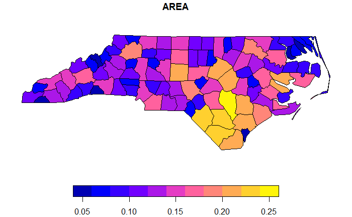

```r
north_carolina <- st_read(system.file("shape/nc.shp", package = "sf"))
plot(north_carolina['AREA'])
```

```r
nrow(north_carolina)
```

```
[1] 100
```

```r
names(north_carolina)
```

```
 [1] "AREA"      "PERIMETER" "CNTY_"     "CNTY_ID"   "NAME"      "FIPS"
 [7] "FIPSNO"    "CRESS_ID"  "BIR74"     "SID74"     "NWBIR74"   "BIR79"
[13] "SID79"     "NWBIR79"   "geometry"
```

```r
nc_geo <- st_geometry(north_carolina)
```

```r
nc_geo[[1]]
```

```
MULTIPOLYGON (((-81.47276 36.23436, -81.54084 36.27251, -81.56198 36.27359, -81.63306 36.34069, -81.74107 36.39178, -81.69828 36.47178, -81.7028 36.51934, -81.67 36.58965, -81.3453 36.57286, -81.34754 36.53791, -81.32478 36.51368, -81.31332 36.4807, -81.26624 36.43721, -81.26284 36.40504, -81.24069 …
```

The “big seven” shapes that a feature can be

1. POINT (1 1)
2. MULTIPOINT ((1 1), (2 2))
3. LINE (1 1, 1 2) 4, MULTILINE ((1 1, 1 2), (2 2, 3 3))
4. POLYGON (1 1, 1 2, 2 2, 2 1, 1 1)
5. MULTIPOLYGON ((1 1, 1 2, 2 2, 2 1, 1 1), (1 1, 1 2, 2 2, 2 1, 1 1))
6. GEOMETRY COLLECTION (POINT (1 1), MULTILINE ((1 1, 1 2), (2 2, 3 3)))

Geometry collection can be made up of multiple shape instructions, and any number of them, just not a geometry collection.

Shetland would be a multipolygon made up of several island polygons.

Can plot individual geometries:

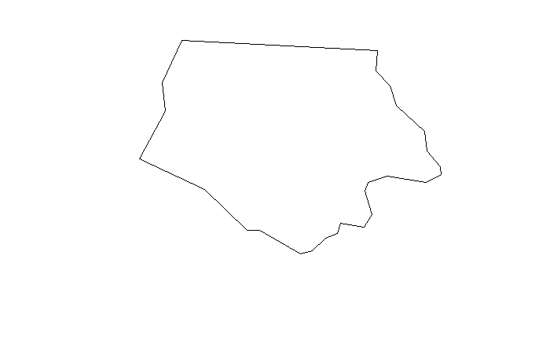

```r
plot(nc_geo[[1]])
```

‘{sf}’ and ‘{ggplot2}’

with a new geom ‘geom_sf’

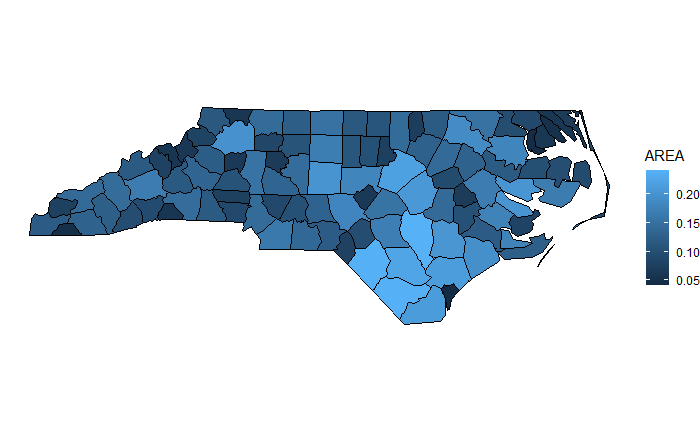

```r
library(tidyverse)

ggplot(north_carolina) +
  geom_sf(aes(fill = AREA), size = 0.1, col = "black") +
  theme_void()
```

```r
class(north_carolina)
```

```
[1] "sf"         "data.frame"
```

Task Try your hand at plotting another feature from the north_carolina dataset. What does it tell you?

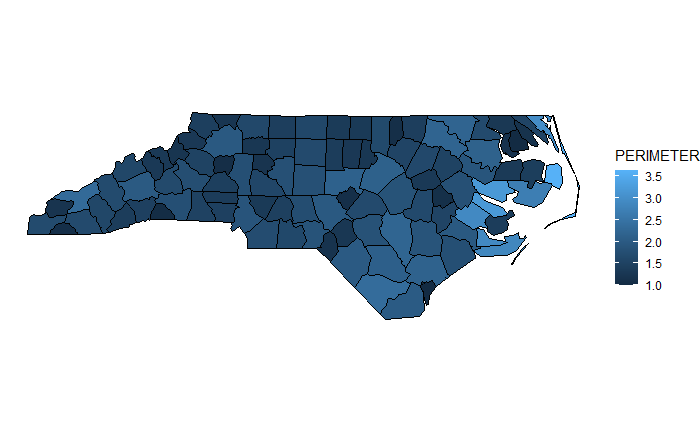

```r
ggplot(north_carolina) +
  geom_sf(aes(fill = PERIMETER), size = 0.1, col = "black") +
  theme_void()
```

```r
names(north_carolina)
```

```
 [1] "AREA"      "PERIMETER" "CNTY_"     "CNTY_ID"   "NAME"      "FIPS"
 [7] "FIPSNO"    "CRESS_ID"  "BIR74"     "SID74"     "NWBIR74"   "BIR79"
[13] "SID79"     "NWBIR79"   "geometry"
```

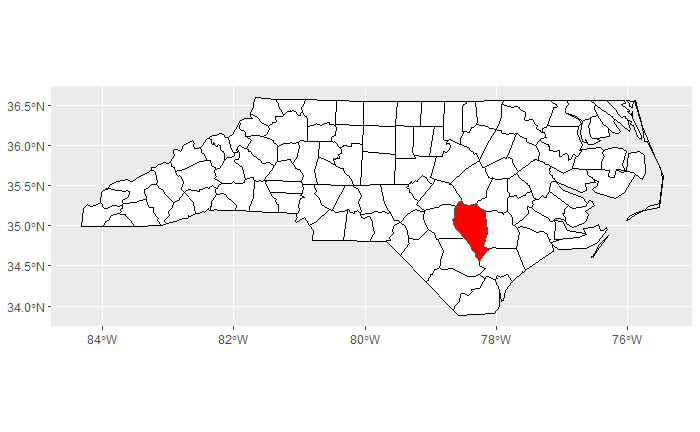

```r
ggplot(north_carolina) +
  geom_sf(fill = "white", colour = "black") +
  geom_sf(data = north_carolina %>%  filter(AREA == max(AREA)), fill = "red")
```

```r
north_carolina %>%
  st_drop_geometry()
```

|  | AREA | PERIMETER | CNTY_ | CNTY_ID | NAME | FIPS | FIPSNO | CRESS_ID | BIR74 | SID74 | NWBIR74 | BIR79 | SID79 | NWBIR79 |
| --- | --- | --- | --- | --- | --- | --- | --- | --- | --- | --- | --- | --- | --- | --- |
| 1 | 0.114 | 1.442 | 1825 | 1825 | Ashe | 37009 | 37009 | 5 | 1091 | 1 | 10 | 1364 | 0 | 19 |
| 2 | 0.061 | 1.231 | 1827 | 1827 | Alleghany | 37005 | 37005 | 3 | 487 | 0 | 10 | 542 | 3 | 12 |
| 3 | 0.143 | 1.630 | 1828 | 1828 | Surry | 37171 | 37171 | 86 | 3188 | 5 | 208 | 3616 | 6 | 260 |
| 4 | 0.070 | 2.968 | 1831 | 1831 | Currituck | 37053 | 37053 | 27 | 508 | 1 | 123 | 830 | 2 | 145 |
| 5 | 0.153 | 2.206 | 1832 | 1832 | Northampton | 37131 | 37131 | 66 | 1421 | 9 | 1066 | 1606 | 3 | 1197 |
| 6 | 0.097 | 1.670 | 1833 | 1833 | Hertford | 37091 | 37091 | 46 | 1452 | 7 | 954 | 1838 | 5 | 1237 |
| 7 | 0.062 | 1.547 | 1834 | 1834 | Camden | 37029 | 37029 | 15 | 286 | 0 | 115 | 350 | 2 | 139 |
| 8 | 0.091 | 1.284 | 1835 | 1835 | Gates | 37073 | 37073 | 37 | 420 | 0 | 254 | 594 | 2 | 371 |
| 9 | 0.118 | 1.421 | 1836 | 1836 | Warren | 37185 | 37185 | 93 | 968 | 4 | 748 | 1190 | 2 | 844 |
| 10 | 0.124 | 1.428 | 1837 | 1837 | Stokes | 37169 | 37169 | 85 | 1612 | 1 | 160 | 2038 | 5 | 176 |

[output cut: 90 more lines]

```r
NA
```

## Subsetting Simple Features

```r
world <- ne_countries(scale = "medium", returnclass = "sf")

names(world)
```

```
 [1] "scalerank"  "featurecla" "labelrank"  "sovereignt" "sov_a3"     "adm0_dif"
 [7] "level"      "type"       "admin"      "adm0_a3"    "geou_dif"   "geounit"
[13] "gu_a3"      "su_dif"     "subunit"    "su_a3"      "brk_diff"   "name"
[19] "name_long"  "brk_a3"     "brk_name"   "brk_group"  "abbrev"     "postal"
[25] "formal_en"  "formal_fr"  "note_adm0"  "note_brk"   "name_sort"  "name_alt"
[31] "mapcolor7"  "mapcolor8"  "mapcolor9"  "mapcolor13" "pop_est"    "gdp_md_est"
[37] "pop_year"   "lastcensus" "gdp_year"   "economy"    "income_grp" "wikipedia"
[43] "fips_10"    "iso_a2"     "iso_a3"     "iso_n3"     "un_a3"      "wb_a2"
[49] "wb_a3"      "woe_id"     "adm0_a3_is" "adm0_a3_us" "adm0_a3_un" "adm0_a3_wb"
[55] "continent"  "region_un"  "subregion"  "region_wb"  "name_len"   "long_len"
[61] "abbrev_len" "tiny"       "homepart"   "geometry"
```

```r
world %>%
  st_drop_geometry() %>%
  head()
```

|  | scalerank | featurecla | labelrank | sovereignt | sov_a3 | adm0_dif | level | type | admin | adm0_a3 | geou_dif | geounit | gu_a3 | su_dif | subunit | su_a3 | brk_diff | name | name_long | brk_a3 | brk_name | brk_group | abbrev | postal | formal_en | formal_fr | note_adm0 | note_brk | name_sort | … |
| --- | --- | --- | --- | --- | --- | --- | --- | --- | --- | --- | --- | --- | --- | --- | --- | --- | --- | --- | --- | --- | --- | --- | --- | --- | --- | --- | --- | --- | --- | --- |
| 0 | 3 | Admin-0 country | 5 | Netherlands | NL1 | 1 | 2 | Country | Aruba | ABW | 0 | Aruba | ABW | 0 | Aruba | ABW | 0 | Aruba | Aruba | ABW | Aruba | NA | Aruba | AW | Aruba | NA | Neth. | NA | Aruba | … |
| 1 | 1 | Admin-0 country | 3 | Afghanistan | AFG | 0 | 2 | Sovereign country | Afghanistan | AFG | 0 | Afghanistan | AFG | 0 | Afghanistan | AFG | 0 | Afghanistan | Afghanistan | AFG | Afghanistan | NA | Afg. | AF | Islamic State of Afghanistan | NA | NA | NA | Afghanistan | … |
| 2 | 1 | Admin-0 country | 3 | Angola | AGO | 0 | 2 | Sovereign country | Angola | AGO | 0 | Angola | AGO | 0 | Angola | AGO | 0 | Angola | Angola | AGO | Angola | NA | Ang. | AO | People's Republic of Angola | NA | NA | NA | Angola | … |
| 3 | 1 | Admin-0 country | 6 | United Kingdom | GB1 | 1 | 2 | Dependency | Anguilla | AIA | 0 | Anguilla | AIA | 0 | Anguilla | AIA | 0 | Anguilla | Anguilla | AIA | Anguilla | NA | Ang. | AI | NA | NA | U.K. | NA | Anguilla | … |
| 4 | 1 | Admin-0 country | 6 | Albania | ALB | 0 | 2 | Sovereign country | Albania | ALB | 0 | Albania | ALB | 0 | Albania | ALB | 0 | Albania | Albania | ALB | Albania | NA | Alb. | AL | Republic of Albania | NA | NA | NA | Albania | … |
| 5 | 3 | Admin-0 country | 6 | Finland | FI1 | 1 | 2 | Country | Aland | ALD | 0 | Aland | ALD | 0 | Aland | ALD | 0 | Aland | Aland Islands | ALD | Aland | NA | Aland | AI | Åland Islands | NA | Fin. | NA | Aland | … |

```r
NA
```

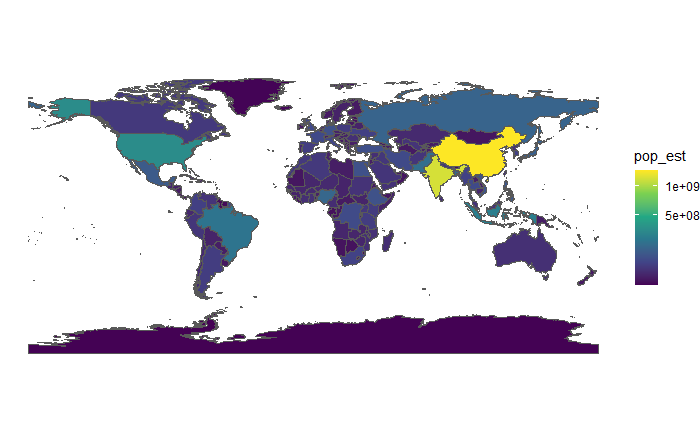

```r
ggplot(world) +
  geom_sf(aes(fill = pop_est), size = 0.1) +
  scale_fill_viridis_c(trans = "sqrt") +
  theme_void()
```

One thing we can do to “better” visualise the different populations between countries is ….> apply a transformation

```r
pop_estimates <- world$pop_est
```

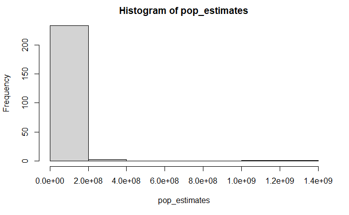

```r
hist(pop_estimates)
```

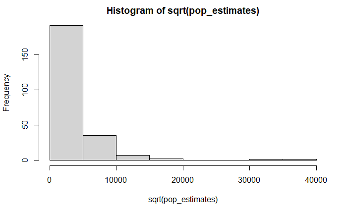

```r
hist(sqrt(pop_estimates))
```

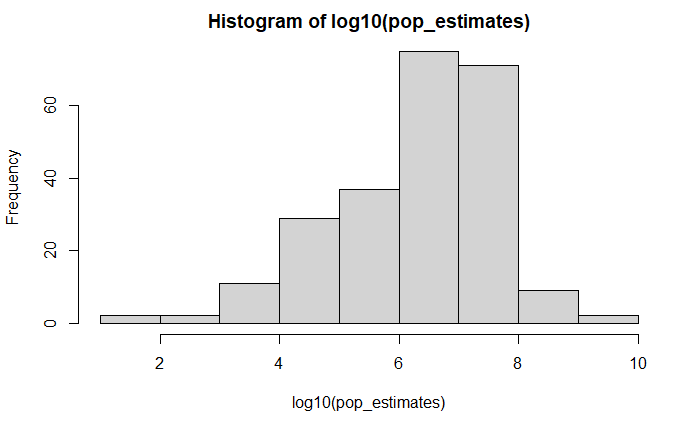

```r
hist(log10(pop_estimates))
```

Task Recap your knowledge from ggplot week, and set your geom_sf aesthetic to be filled with the estimated gdp (gdp_md_est variable). Extra points if you make your map colour blind friendly! What does your plot tell you? What does it tell you compared to the population?

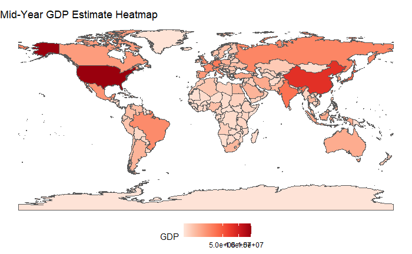

```r
world %>%
  ggplot(aes(fill = gdp_md_est)) +
  geom_sf(size = 0.1) +
  scale_fill_distiller(palette = "Reds", direction = 1, trans = "sqrt") +
  theme_void() +
  labs(fill = "GDP",
       title = "Mid-Year GDP Estimate Heatmap") +
  theme(legend.position = "bottom")
```

```r
NA
NA
```

Picking out individual countries

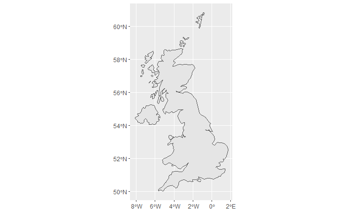

```r
world %>%
  filter(name == "United Kingdom") %>%
  ggplot() +
  geom_sf()
```

Zooming in on particular areas

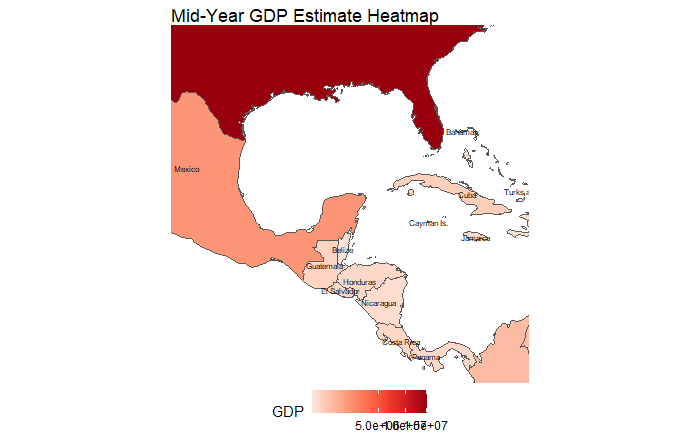

```r
world %>%
  ggplot(aes(fill = gdp_md_est)) +
  geom_sf(size = 0.1) +
  geom_sf_text(aes(label = name), size = 2, check_overlap = TRUE) +
  coord_sf(xlim = c(-102.15, -74.12), ylim = c(7.65, 33.9)) +
  scale_fill_distiller(palette = "Reds", direction = 1, trans = "sqrt") +
  theme_void() +
  labs(fill = "GDP",
       title = "Mid-Year GDP Estimate Heatmap") +
  theme(legend.position = "bottom")
```

Creating Static Geospatial Data Visualisations

Creating Interactive Geospatial Data Visualisations

‘{leaflet}’

```r
library(leaflet)
```

Individual Markers

```r
leaflet() %>%
  addTiles() %>%
  addMarkers(
    lng = 174.768,
    lat = -36.852,
    popup = "Birthplace of R"
  )
```

[interactive chart not shown]

```r
NA
```

Circle markers

```r
library(jsonlite)

data_url <- "https://data.colorado.gov/resource/j5pc-4t32.json?&county=BOULDER"

water_data <- fromJSON(data_url) %>%
  jsonlite::flatten(recursive = TRUE)
```

Data preparation

amount, latitude and longitude are not numeric data types, but they should be

```r
water_data_clean <- water_data %>%
  mutate(across(
    c(amount, location.latitude, location.longitude),
    as.numeric
  )) %>%
  filter(!is.na(location.latitude))

water_data_clean
```

| station_name | div | dwr_abbrev | data_source | amount | station_type | wd | date_time | county | variable | stage | station_status | usgs_station_id | flag | location.latitude | location.needs_recoding | location.longitude | http_linkage.url |
| --- | --- | --- | --- | --- | --- | --- | --- | --- | --- | --- | --- | --- | --- | --- | --- | --- | --- |
| SOUTH BOULDER CREEK NEAR ELDORADO SPRINGS, CO. | 1 | BOCELSCO | Co. Division of Water Resources | 35.10 | Stream | 6 | 2022-08-23T08:15:00.000 | BOULDER | DISCHRG | 2.38 | Active | NA | NA | 39.93160 | FALSE | -105.3050 | https://dwr.state.co.us/Tools/Stations/BOCELSCO |
| MIDDLE SAINT VRAIN AT PEACEFUL VALLEY | 1 | MIDSTECO | Co. Division of Water Resources | 20.30 | Stream | 5 | 2022-08-23T09:00:00.000 | BOULDER | DISCHRG | 2.62 | Active | NA | NA | 40.12981 | FALSE | -105.5171 | https://dwr.state.co.us/Tools/Stations/MIDSTECO |
| BOULDER RESERVOIR DELIVERY TO BOULDER-LEFT HAND DITCH | 1 | BLDRLHCO | Northern Water | 2.07 | Diversion | 5 | 2022-08-23T08:00:00.000 | BOULDER | DISCHRG | 0.66 | Active | NA | NA | 40.07584 | FALSE | -105.2017 | https://dwr.state.co.us/Tools/Stations/BLDRLHCO |
| HOWELL DITCH NORTH FLUME | 1 | HONDITCO | Co. Division of Water Resources | 0.00 | Diversion | 6 | 2022-08-23T08:15:00.000 | BOULDER | DISCHRG | NA | Active | NA | NA | 40.07401 | FALSE | -105.0745 | https://dwr.state.co.us/Tools/Stations/HONDITCO |
| LONGMONT SUPPLY DITCH | 1 | LONSUPCO | Cooperative Program of CDWR, NCWCD & SVLHWCD | 3.68 | Diversion | 5 | 2022-08-23T08:00:00.000 | BOULDER | DISCHRG | 0.47 | Active | NA | NA | 40.20420 | FALSE | -105.2188 | https://dwr.state.co.us/Tools/Stations/LONSUPCO |
| SUPPLY DITCH | 1 | SUPDITCO | Cooperative Program of CDWR, NCWCD & SVLHWCD | 0.00 | Diversion | 5 | 2022-08-23T07:30:00.000 | BOULDER | DISCHRG | -0.01 | Active | NA | NA | 40.21905 | FALSE | -105.2598 | https://dwr.state.co.us/Tools/Stations/SUPDITCO |
| BOULDER CREEK NEAR ORODELL, CO. | 1 | BOCOROCO | Co. Division of Water Resources | 63.10 | Stream | 6 | 2022-08-23T08:15:00.000 | BOULDER | DISCHRG | 2.15 | Active | 06727000 | NA | 40.00653 | FALSE | -105.3305 | https://dwr.state.co.us/Tools/Stations/BOCOROCO |
| FARMERS DITCH | 1 | FARDITCO | Co. Division of Water Resources | 13.80 | Diversion | 6 | 2022-08-23T09:00:00.000 | BOULDER | DISCHRG | NA | Active | NA | NA | 40.01398 | FALSE | -105.2957 | https://dwr.state.co.us/Tools/Stations/FARDITCO |
| MIDDLE BOULDER CREEK AT NEDERLAND, CO. | 1 | BOCMIDCO | Co. Division of Water Resources | 38.80 | Stream | 6 | 2022-08-23T08:15:00.000 | BOULDER | DISCHRG | 1.22 | Active | 06725500 | NA | 39.96166 | FALSE | -105.5045 | https://dwr.state.co.us/Tools/Stations/BOCMIDCO |
| PECK-PELLA AUGMENTATION RETURN | 1 | PECRTNCO | Co. Division of Water Resources | 0.00 | Diversion | 5 | 2022-08-23T08:00:00.000 | BOULDER | DISCHRG | NA | Active | NA | NA | 40.16071 | FALSE | -105.1685 | https://dwr.state.co.us/Tools/Stations/PECRTNCO |

[output cut: 93 more lines]

```r
NA
```

```r
leaflet(water_data_clean) %>%
  addTiles() %>%
  addCircles(
    lng = ~location.longitude,
    lat = ~location.latitude,
    # make the size depend on the amount of water at that location
    radius = ~amount/10,
    # create data dependent popups - paste or create a string for the labels
    popup = ~paste("water", amount)
  )
```

[interactive chart not shown]

```r
NA
```

## Clustering

```r
leaflet(water_data_clean) %>%
  addTiles() %>%
  addMarkers(
    lng = ~location.longitude,
    lat = ~location.latitude,
    popup = ~paste("water", amount),
    clusterOptions = markerClusterOptions()
  )
```

[interactive chart not shown]

```r
NA
```

## Reading/Weiting Shapefiles

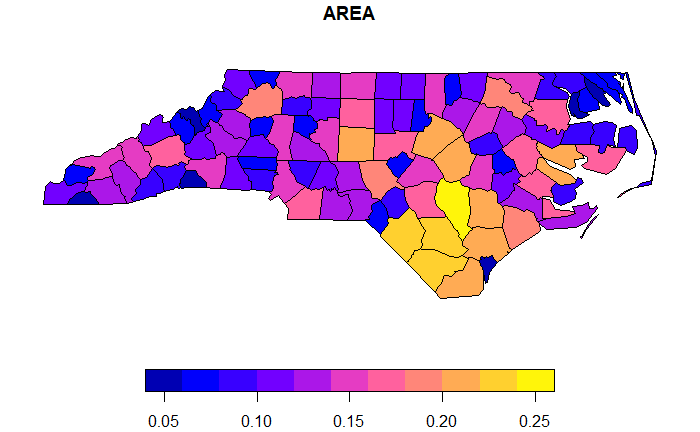

```r
plot(north_carolina['AREA'])
```

[figure not shown]

```r
plot(nc_geo[[4]])
```

[figure not shown]

```r
plot(st_simplify(nc_geo, dTolerance = 2000)[[4]])
```

simplify, increasing the tolerance will decrease the number of points to express that polygon

by simplifying, we can reduce computational runtime (an important resource in shiny apps)

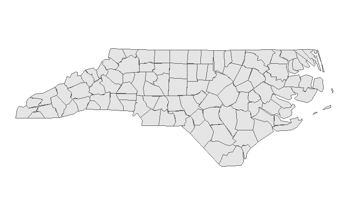

```r
north_carolina %>%
  st_simplify(dTolerance = 2000) %>%
  ggplot() +
  geom_sf() +
  theme_void()
```

reading/writing shapefiles

```r
# not standard to read in a system file, that was mostly for an example
# st_read(system.file())
```

```r
north_carolina %>%
  st_simplify(dTolerance = 2000) %>%
  st_write(dsn = "nc_simplified",
           layer = "simple_north_carolina",
           driver = "ESRI Shapefile")
```

[output not shown]

[output not shown]

shapefiles { - .shp - .shx - .prj - .dbf }

Usual way we read in shapefiles:

```r
north_carolina_simple <- st_read(
  dsn = "nc_simplified/",
  layer = "simple_north_carolina"
  )
```

## Leaflet Polygons

```r
pal <- colorBin("Purples", north_carolina_simple$NWBIR74, n = 5)

labels <- paste(
  "<b>", north_carolina_simple$NAME, "</b>", "<br>",
  north_carolina_simple$NWBIR74
) %>%  lapply(htmltools::HTML)

north_carolina_simple %>%
  st_transform(crs = "+proj=longlat +datum=WGS84") %>%
  leaflet() %>%
  addTiles() %>%
  addPolygons(
    weight = 1,
              col = "black",
              fillColor = ~pal(NWBIR74),
              fillOpacity = 100,
              label = labels
    ) %>%
  addLegend(
    pal = pal,
    values = ~NWBIR74,
    position = "bottomright"
    )
```

[interactive chart not shown]

```r
NA
```